# Networks: structure, evolution & processes

### 2.3.1 Stop the apocalypse!

```python
'''
Computes and prints the average percentage of S,I and R people after an epidemic in a graph

args :
    - The basic graph that we start from (NewYork roads for us)
    - strategy, the function of edge suppression (either delete_random or smarter_strategy)
    - the number of nodes to be deleted by this strategy
    - the simulation time
    - the number of simulations for our mean

'''

def get_average_status (basic_graph, strategy, nb_nodes_to_delete=2500, simulation_time=30, nb_simulations=50 ) :

    order = G.order()

    sumS = 0 #susceptible
    sumI = 0 #infected
    sumR = 0 #recovered

    # ======== Simulation of 'nb_simulations' cases ========
    for j in range (nb_simulations) :

        # inner counters
        inner_s = 0
        inner_i = 0
        inner_r = 0

        # ======== Inside this with-statement, functions are not allowed to print ========
        with io.capture_output() as captured:



            # Create a modified graph to avoid the epidemic expansion
            newG = strategy(basic_graph, nb_nodes_to_delete)
            new_sir = epidemics_helper.SimulationSIR(newG, 10.0, 0.1)

            #launch the epidemic
            random_node = np.random.choice(newG.nodes())
            new_sir.launch_epidemic(random_node, simulation_time)

        # ========== no print-ban anymore ==========



        # ========== Computation ==========

        for s in new_sir.status:
            if s == 0 :
                inner_s += 1
            elif s == 1 :
                inner_i += 1
            else :
                inner_r += 1


        # Compute the inner percentage of S,I,R people

        sumS += inner_s*100.0 / order
        sumI += inner_i*100.0 / order
        sumR += inner_r*100.0 / order


        print_state(j, 1, nb_simulations)


    print("\r100 %")

    print("\n\nAfter ", simulation_time, " days and after deleting", nb_nodes_to_delete ," nodes, there are in average :")
    print( float(sumS) / nb_simulations, " % of healthy people")
    print( float(sumI) / nb_simulations, " % of infected people")
    print( float(sumR) / nb_simulations, " % of recovered(dead) people")
```

#### Exercise 2.10: Strategy 1

The first 'naive' strategy is defined in the cell below :

```python
'''
This function deletes n edges at random in the graph G
It returns the modified graph
'''

def delete_random(G, n):

    newG = G.copy()
    new_nodes = newG.nodes()


    for k in range(n):

        #take a random node
        node_1 = np.random.choice(new_nodes)
        nei = newG.neighbors(node_1)

        #if this node still has at least one neighbor
        if (len(nei) > 0):

            #remove a random edge between node_1 and one of its neighbors
            node_2 = np.random.choice(nei)
            newG.remove_edge(node_1, node_2)

        #otherwise, we decrement i because we did not delete any edge during this iteration
        else :
            k -= 1

        print_state(k, 13, n)


    print("\r100 %")

    return newG
```

##### Simultate the epidemic destroying 10000 edges :

```python
G2 = delete_random(G,10000)
sir2 = epidemics_helper.SimulationSIR(G2, 10.0, 0.1)

random_node = np.random.choice(G2.nodes())
sir2.launch_epidemic(random_node, 100)
```

```
100 %
Epidemic stopped after 100.30 days | 100.30 days elapsed | 25.3% susceptible, 0.0% infected, 74.6% recovered
```

Running the above cell several times let us see that this strategy is far from being effective. Even with deleting 10k edges, the infection mostly spreads.

##### The cell below gives the average statistics

```python
get_average_status(G, delete_random, nb_nodes_to_delete=1000, nb_simulations=10)
```

```
100 %


After  30  days and after deleting 1000  nodes, there are in average :
0.6144027793512329  % of healthy people
10.756013745704468  % of infected people
88.6295834749443  % of recovered(dead) people
```

This is clearly not an effective strategy

#### Exercise 2.11: Strategy 2

Our strategy below uses the fact that some nodes are only the source of 2 edges.

Those nodes are thus critical points because if we cut one of those 2 edges, the epidemic cannot evolves through this point anymore.

So we begin by destroying one connection for every node that has 2 edges. Then if we have some 'iteration' left, we apply the algorithm derived from the friends paradox that we studied in class.

##### Extracting nodes with only 2 neighbors (bottleneck nodes)

```python
# ======== Init ========
two_neighbors_nodes = np.array(())
all_other_nodes = np.array(())

# ======== Filling the first list ========
for nd in G.nodes():
    if (len(G.neighbors(nd)) == 2):
        two_neighbors_nodes = np.append(two_neighbors_nodes, nd)

# ======== Filling the second list ========
all_other_nodes = np.setdiff1d(G.nodes(), two_neighbors_nodes, assume_unique=True)
```

```python
'''
This function deletes n edges at random in the graph G
It returns the modified graph
'''

def smarter_strategy(G, n):

    #To be returned
    newG = G.copy()

    for i in range (n):


        # ========== Deleting bottleneck edges ==========

        if (i < len(two_neighbors_nodes)) :


            # Deleting one edge of a node with 2 edges only (like a bridge !)
            n = two_neighbors_nodes[i]
            nei = newG.neighbors(n)

            if (len(nei) != 0) : #Could happen if we already deleted the edges of this point
                newG.remove_edge(n, nei[0])


        # ========== Applying the friends paradox (level 2) ==========

        else:

            # Choose a first node
            node_1 = np.random.choice(all_other_nodes)
            neighbors = newG.neighbors(node_1)


            if (len(neighbors) != 0) :

                # Choose a second node
                node_2 = np.random.choice(neighbors)
                neighbors_2 = newG.neighbors(node_2)

                if (len(neighbors_2) != 0) :

                    # Choose a third node
                    node_3 = np.random.choice(neighbors_2)

                    # Delete the edge (node_2, node_3)
                    newG.remove_edge(node_2, node_3)


        print_state(i, 13, n)

    print("\r100 %")
    return newG
```

```python
#======== Apply our new strategy =========

G3 = smarter_strategy(G,2500)
sir3 = epidemics_helper.SimulationSIR(G3, 10.0, 0.1)

random_node = np.random.choice(G3.nodes())
sir3.launch_epidemic(random_node, 30)
```

```
100 %
Epidemic stopped after 30.01 days | 30.01 days elapsed | 94.7% susceptible, 0.4% infected, 4.9% recovered
```

__

Draw the result of the epidemic created above :

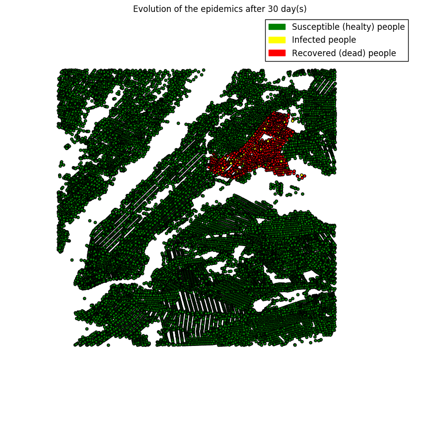

```python
draw_epidemics(G3, sir3, 30) #After 30 days
```

The cell below prints the average status

```python
get_average_status(G,smarter_strategy)
```

```
100 %


After  30  days and after deleting 2500  nodes, there are in average :
74.63977946452172  % of healthy people
1.8614100675956344  % of infected people
23.49881046788264  % of recovered(dead) people
```

We see that our new implementation is clearly more efficient than the first one !

###### We can even do better than the TAs !